# Graded Novelty Enoding Task - 4 shapes version

# Exclusions

In total, the task was run 61 times.

6 runs were not completed or were duplicates.

We excluded 3 participants due to low performance in the study phase. We calculated the confidence intervals for the probability of correct “old” responses and excluded those participants whose lower CI was below 0.33 (chance level - 25 opportunities for correct “old” response, 50 for incorrect).

We excluded 2 participants due to missed responses in test phase (<= 20).

This left 50 participants in the analysis.

The sample had a mean(±sd) age of 22.02 ± 4.821254.

The sample contained 45 women.

# Comparison with GNET 1

The recognition of the prototypes compared between studies (original GNET with 5 shapes).

```
##
##  Welch Two Sample t-test
##
## data:  a and b
## t = -3.6777, df = 124.95, p-value = 0.0003482
## alternative hypothesis: true difference in means is not equal to 0
## 95 percent confidence interval:
##  -0.14552424 -0.04369681
## sample estimates:
## mean of x mean of y
## 0.6597895 0.7544000
```

```
##
## Cohen's d
##
## d estimate: -0.5908296 (medium)
## 95 percent confidence interval:
##      lower      upper
## -0.9429363 -0.2387228
```

The distribution of the data is not normal (original GNET):

```
##
##  Shapiro-Wilk normality test
##
## data:  a
## W = 0.96925, p-value = 0.02462
```

The distribution of the data is not normal (current GNET):

```
##
##  Shapiro-Wilk normality test
##
## data:  b
## W = 0.93748, p-value = 0.01073
```

Use a non-parametric alternative for the Welch test - Mann-Whitney-Wilcoxon U test

```
##
##  Wilcoxon rank sum test with continuity correction
##
## data:  a and b
## W = 1553.5, p-value = 0.0006097
## alternative hypothesis: true location shift is not equal to 0
## 95 percent confidence interval:
##  -0.15997825 -0.04000147
## sample estimates:
## difference in location
##             -0.0800681
```

The overall correct categorizations in the test phase

```
##
##  Shapiro-Wilk normality test
##
## data:  a
## W = 0.99288, p-value = 0.8982
```

```
##
##  Shapiro-Wilk normality test
##
## data:  b
## W = 0.98034, p-value = 0.5665
```

The performance on the recognition test compared with a Welch test

```
##
##  Welch Two Sample t-test
##
## data:  a and b
## t = -0.90224, df = 104.43, p-value = 0.369
## alternative hypothesis: true difference in means is not equal to 0
## 95 percent confidence interval:
##  -0.8859586  0.3318534
## sample estimates:
## mean of x mean of y
## 0.4589474 0.7360000
```

```
##
## Cohen's d
##
## d estimate: -0.1550763 (negligible)
## 95 percent confidence interval:
##      lower      upper
## -0.5009085  0.1907558
```

# Study phase

ANOVA to compare the rejection rate for each difference category; plot shows the prototype recog rate also.

```
## Anova Table (Type 3 tests)
##
## Response: crrate
##     Effect           df  MSE         F  ges p.value
## 1 stimtype 2.72, 133.45 0.02 28.56 *** .175   <.001
## ---
## Signif. codes:  0 '***' 0.001 '**' 0.01 '*' 0.05 '+' 0.1 ' ' 1
##
## Sphericity correction method: GG
```

```
##  contrast estimate     SE  df t.ratio p.value
##  D1 - D2    -0.072 0.0216 196  -3.327 0.0092
##  D1 - D3    -0.098 0.0216 196  -4.529 0.0001
##  D1 - D4    -0.142 0.0216 196  -6.562 <.0001
##  D1 - D5    -0.220 0.0216 196 -10.166 <.0001
##  D2 - D3    -0.026 0.0216 196  -1.201 0.7505
##  D2 - D4    -0.070 0.0216 196  -3.235 0.0123
##  D2 - D5    -0.148 0.0216 196  -6.839 <.0001
##  D3 - D4    -0.044 0.0216 196  -2.033 0.2541
##  D3 - D5    -0.122 0.0216 196  -5.638 <.0001
##  D4 - D5    -0.078 0.0216 196  -3.604 0.0036
##
## P value adjustment: tukey method for comparing a family of 5 estimates
```

```
##  contrast  estimate     SE  df t.ratio p.value
##  linear       0.510 0.0484 196 10.540  <.0001
##  quadratic    0.030 0.0573 196  0.524  0.6009
##  cubic        0.080 0.0484 196  1.653  0.0999
##  quartic     -0.048 0.1280 196 -0.375  0.7081
```

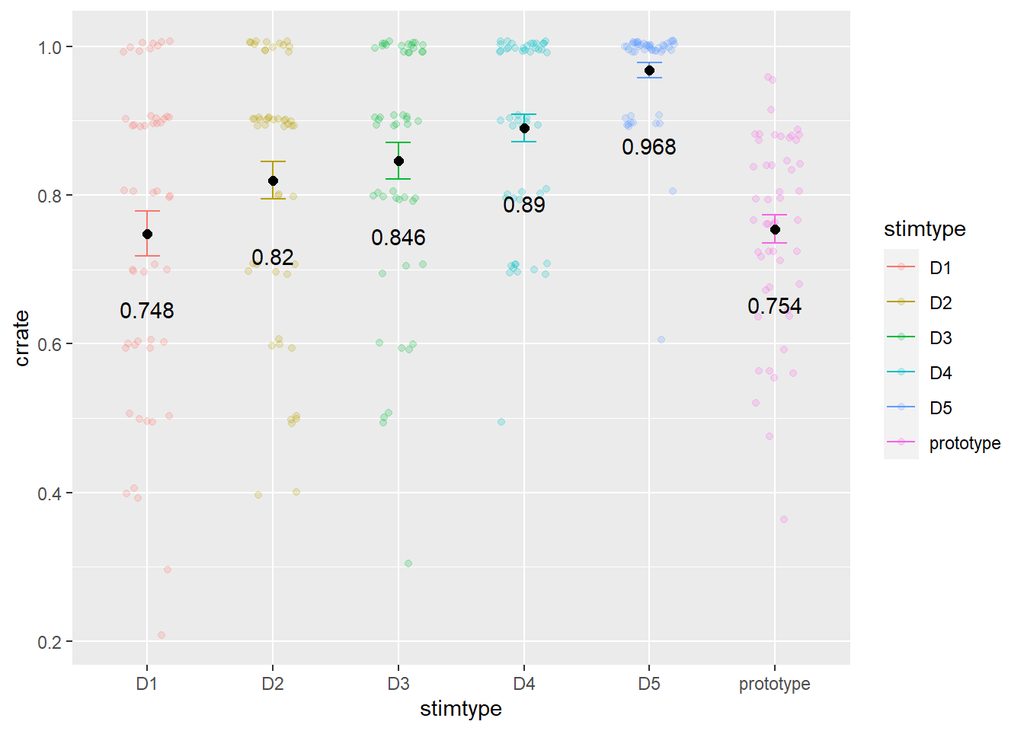

# Test phase

```
##
##  Paired t-test
##
## data:  a and b
## t = 3.1141, df = 249, p-value = 0.002061
## alternative hypothesis: true difference in means is not equal to 0
## 95 percent confidence interval:
##  0.1396684 0.6203316
## sample estimates:
## mean of the differences
##                    0.38
```

```
##
## Cohen's d
##
## d estimate: 0.1727688 (negligible)
## 95 percent confidence interval:
##      lower      upper
## 0.06295669 0.28258087
```

```
##
##  Shapiro-Wilk normality test
##
## data:  d
## W = 0.96992, p-value = 3.954e-05
```

```
## [1] "Correct recognition for familiars in test"
```

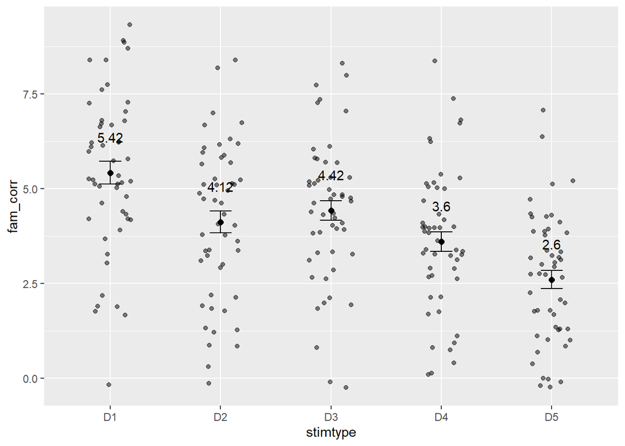

```
## [1] "False alarm for novels in test"
```

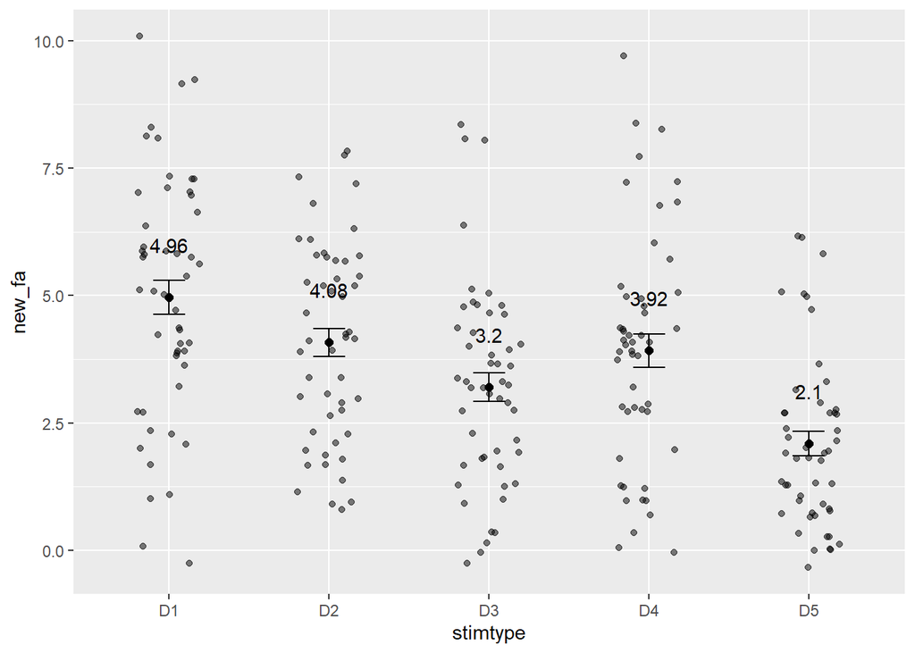

```
## [1] "ANOVA with correct recognition minus false alarm or miss by fam/nov"
```

```
## Anova Table (Type 3 tests)
##
## Response: CorrectedRecognitions
##     Effect           df  MSE       F  ges p.value
## 1 stimtype 3.52, 172.63 4.03 4.69 ** .072    .002
## ---
## Signif. codes:  0 '***' 0.001 '**' 0.01 '*' 0.05 '+' 0.1 ' ' 1
##
## Sphericity correction method: GG
```

```
##  contrast estimate    SE  df t.ratio p.value
##  D1 - D2      0.42 0.377 196  1.115  0.7986
##  D1 - D3     -0.76 0.377 196 -2.017  0.2615
##  D1 - D4      0.78 0.377 196  2.070  0.2371
##  D1 - D5     -0.04 0.377 196 -0.106  1.0000
##  D2 - D3     -1.18 0.377 196 -3.132  0.0169
##  D2 - D4      0.36 0.377 196  0.956  0.8745
##  D2 - D5     -0.46 0.377 196 -1.221  0.7391
##  D3 - D4      1.54 0.377 196  4.088  0.0006
##  D3 - D5      0.72 0.377 196  1.911  0.3148
##  D4 - D5     -0.82 0.377 196 -2.177  0.1929
##
## P value adjustment: tukey method for comparing a family of 5 estimates
```

```
##  contrast  estimate    SE  df t.ratio p.value
##  linear       -0.28 0.842 196 -0.332  0.7399
##  quadratic    -0.24 0.997 196 -0.241  0.8100
##  cubic         0.76 0.842 196  0.902  0.3681
##  quartic       9.40 2.229 196  4.218  <.0001
```

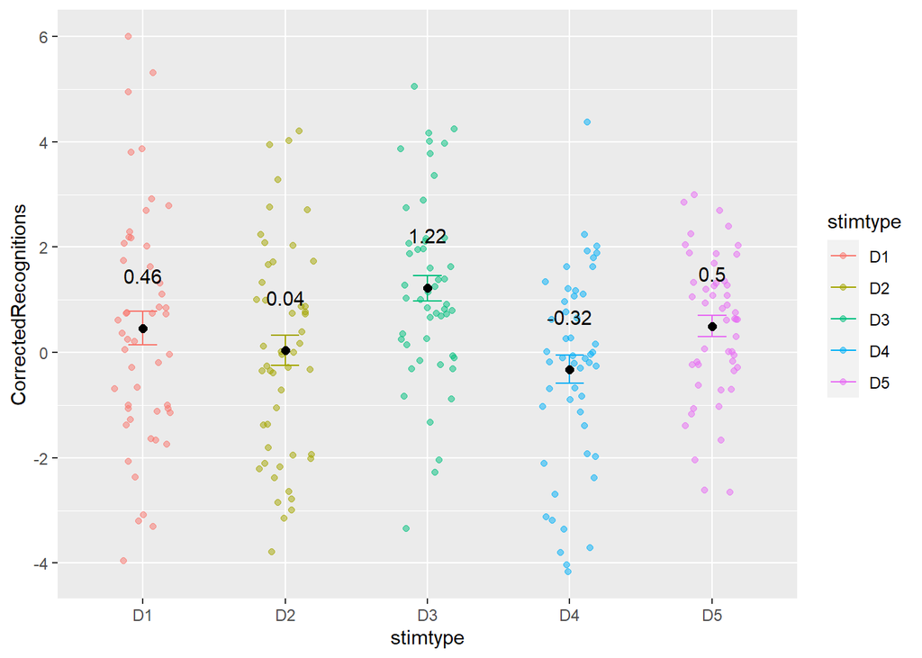

```
## [1] "ANOVA with correct rejection minus false alarm or miss by fam/nov"
```

```
## Anova Table (Type 3 tests)
##
## Response: CorrectedRejections
##     Effect           df  MSE      F  ges p.value
## 1 stimtype 3.28, 160.64 5.13 3.65 * .056    .011
## ---
## Signif. codes:  0 '***' 0.001 '**' 0.01 '*' 0.05 '+' 0.1 ' ' 1
##
## Sphericity correction method: GG
```

```
##  contrast estimate   SE  df t.ratio p.value
##  D1 - D2      0.38 0.41 196  0.927  0.8862
##  D1 - D3     -0.84 0.41 196 -2.049  0.2467
##  D1 - D4      0.62 0.41 196  1.512  0.5556
##  D1 - D5      0.06 0.41 196  0.146  0.9999
##  D2 - D3     -1.22 0.41 196 -2.976  0.0269
##  D2 - D4      0.24 0.41 196  0.585  0.9771
##  D2 - D5     -0.32 0.41 196 -0.781  0.9360
##  D3 - D4      1.46 0.41 196  3.562  0.0042
##  D3 - D5      0.90 0.41 196  2.196  0.1857
##  D4 - D5     -0.56 0.41 196 -1.366  0.6501
##
## P value adjustment: tukey method for comparing a family of 5 estimates
```

```
##  contrast  estimate    SE  df t.ratio p.value
##  linear       -0.36 0.917 196 -0.393  0.6949
##  quadratic    -0.80 1.085 196 -0.738  0.4616
##  cubic         0.42 0.917 196  0.458  0.6473
##  quartic       8.98 2.425 196  3.703  0.0003
```

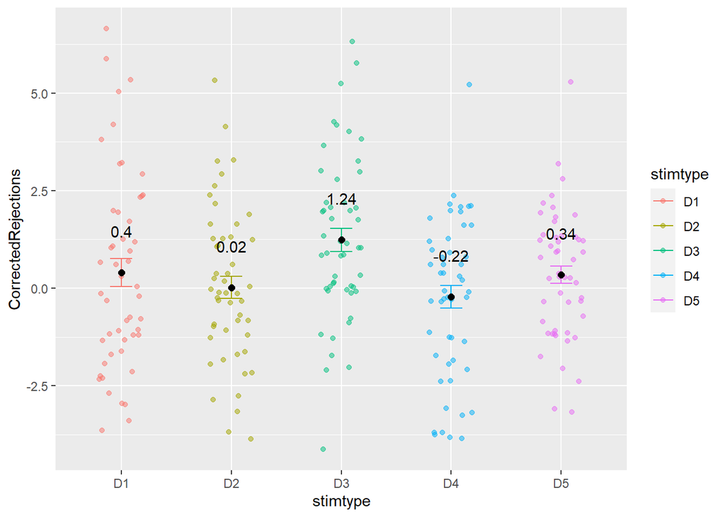

```
## [1] "ANOVA with corrected differentiation score by category ((crecog-fa)+(creject-fa))"
```

```
## Anova Table (Type 3 tests)
##
## Response: OCCategorizations
##     Effect           df   MSE       F  ges p.value
## 1 stimtype 3.39, 166.15 17.45 4.30 ** .065    .004
## ---
## Signif. codes:  0 '***' 0.001 '**' 0.01 '*' 0.05 '+' 0.1 ' ' 1
##
## Sphericity correction method: GG
```

```
##  contrast estimate    SE  df t.ratio p.value
##  D1 - D2      0.80 0.769 196  1.040  0.8364
##  D1 - D3     -1.60 0.769 196 -2.080  0.2329
##  D1 - D4      1.40 0.769 196  1.820  0.3650
##  D1 - D5      0.02 0.769 196  0.026  1.0000
##  D2 - D3     -2.40 0.769 196 -3.120  0.0176
##  D2 - D4      0.60 0.769 196  0.780  0.9361
##  D2 - D5     -0.78 0.769 196 -1.014  0.8487
##  D3 - D4      3.00 0.769 196  3.900  0.0012
##  D3 - D5      1.62 0.769 196  2.106  0.2217
##  D4 - D5     -1.38 0.769 196 -1.794  0.3800
##
## P value adjustment: tukey method for comparing a family of 5 estimates
```

```
##  contrast  estimate   SE  df t.ratio p.value
##  linear       -0.64 1.72 196 -0.372  0.7102
##  quadratic    -1.04 2.04 196 -0.511  0.6099
##  cubic         1.18 1.72 196  0.686  0.4935
##  quartic      18.38 4.55 196  4.039  0.0001
```

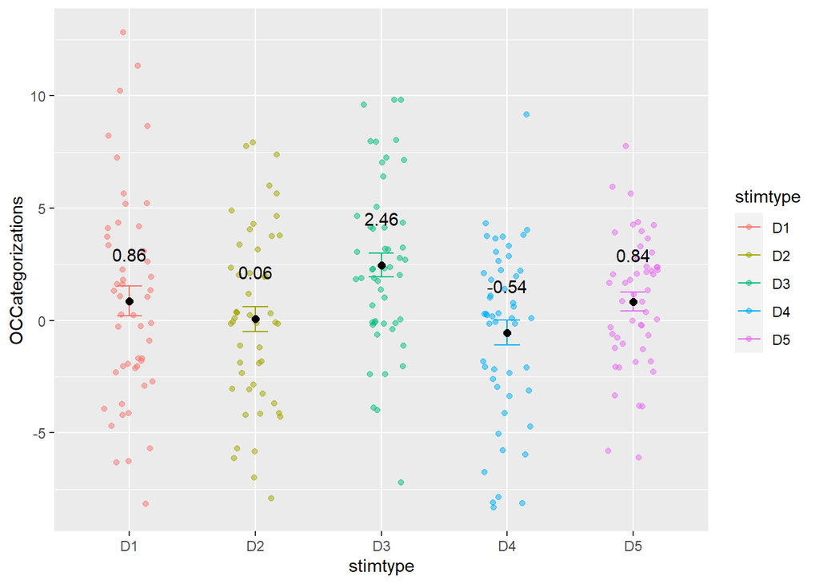

# Mixed models

## Test phase

### Models #1

```
## Generalized linear mixed model fit by maximum likelihood (Laplace
##   Approximation) [glmerMod]
##  Family: binomial  ( logit )
## Formula: rt_resp ~ stimtype * test_quality + (1 | workerId)
##    Data: tdlmm
## Control: lmerControl(optCtrl = list(xtol_abs = 1e-08, ftol_abs = 1e-08,
##     maxeval = 1e+05))
##
##      AIC      BIC   logLik deviance df.resid
##   5967.9   6039.2  -2973.0   5945.9     4797
##
## Scaled residuals:
##     Min      1Q  Median      3Q     Max
## -4.3587 -0.9446  0.4841  0.7939  2.4176
##
## Random effects:
##  Groups   Name        Variance Std.Dev.
##  workerId (Intercept) 0.475    0.6892
## Number of obs: 4808, groups:  workerId, 50
##
## Fixed effects:
##                            Estimate Std. Error z value Pr(>|z|)
## (Intercept)                -0.26323    0.13728  -1.917  0.05518 .
## stimtypeD2                  0.57674    0.13680   4.216 2.49e-05 ***
## stimtypeD3                  0.44663    0.13636   3.275  0.00105 **
## stimtypeD4                  0.83025    0.13820   6.008 1.88e-09 ***
## stimtypeD5                  1.38205    0.14390   9.604  < 2e-16 ***
## test_qualitynew             0.19773    0.13627   1.451  0.14679
## stimtypeD2:test_qualitynew -0.18787    0.19323  -0.972  0.33092
## stimtypeD3:test_qualitynew  0.38552    0.19491   1.978  0.04793 *
## stimtypeD4:test_qualitynew -0.33170    0.19417  -1.708  0.08758 .
## stimtypeD5:test_qualitynew  0.08455    0.20689   0.409  0.68277
## ---
## Signif. codes:  0 '***' 0.001 '**' 0.01 '*' 0.05 '.' 0.1 ' ' 1
##
## Correlation of Fixed Effects:
##             (Intr) stmtD2 stmtD3 stmtD4 stmtD5 tst_ql stD2:_ stD3:_ stD4:_
## stimtypeD2  -0.497
## stimtypeD3  -0.498  0.501
## stimtypeD4  -0.492  0.495  0.497
## stimtypeD5  -0.473  0.477  0.478  0.473
## test_qltynw -0.499  0.501  0.503  0.496  0.477
## stmtypD2:t_  0.352 -0.707 -0.354 -0.350 -0.336 -0.705
## stmtypD3:t_  0.349 -0.349 -0.699 -0.346 -0.332 -0.699  0.493
## stmtypD4:t_  0.350 -0.352 -0.353 -0.711 -0.335 -0.702  0.495  0.490
## stmtypD5:t_  0.328 -0.330 -0.331 -0.326 -0.691 -0.659  0.464  0.460  0.462
```

```
## Package `effects` is not available, but needed for `ggeffect()`. Either install package `effects`, or use `ggpredict()`. Calling `ggpredict()` now.FALSE
```

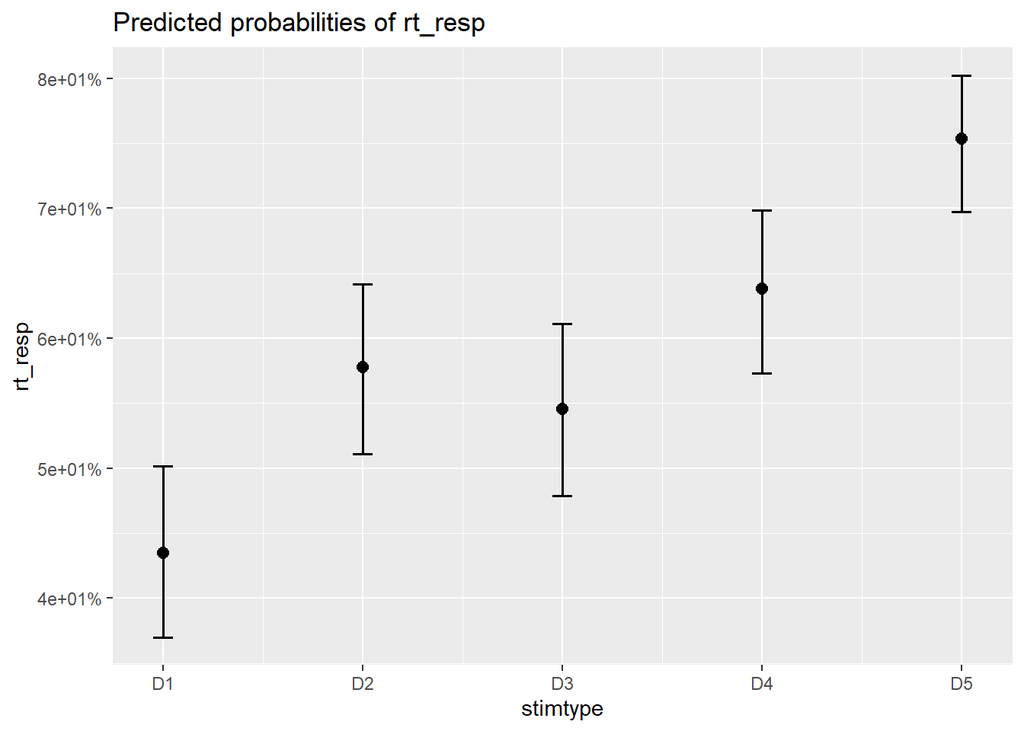

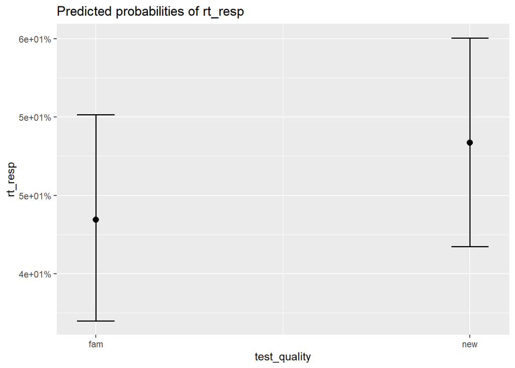

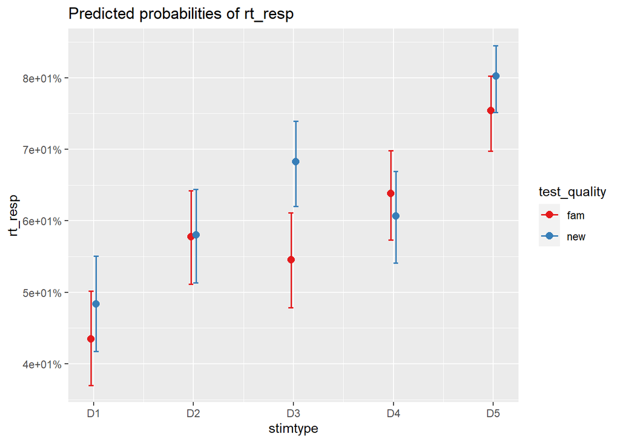

```
## Generalized linear mixed model fit by maximum likelihood (Laplace
##   Approximation) [glmerMod]
##  Family: binomial  ( logit )
## Formula: rt_resp ~ DTF * test_quality + (1 | workerId)
##    Data: tdlmm
##
##      AIC      BIC   logLik deviance df.resid
##   5995.5   6027.9  -2992.8   5985.5     4803
##
## Scaled residuals:
##     Min      1Q  Median      3Q     Max
## -4.7514 -0.9641  0.4891  0.7979  2.2285
##
## Random effects:
##  Groups   Name        Variance Std.Dev.
##  workerId (Intercept) 0.4669   0.6833
## Number of obs: 4808, groups:  workerId, 50
##
## Fixed effects:
##                       Estimate Std. Error z value Pr(>|z|)
## (Intercept)         -0.3147047  0.1269721  -2.479   0.0132 *
## DTF                  0.1014509  0.0106341   9.540   <2e-16 ***
## test_qualitynew      0.2017522  0.1181747   1.707   0.0878 .
## DTF:test_qualitynew -0.0008351  0.0156063  -0.054   0.9573
## ---
## Signif. codes:  0 '***' 0.001 '**' 0.01 '*' 0.05 '.' 0.1 ' ' 1
##
## Correlation of Fixed Effects:
##             (Intr) DTF    tst_ql
## DTF         -0.546
## test_qltynw -0.450  0.587
## DTF:tst_qlt  0.371 -0.678 -0.848
```

```
## Package `effects` is not available, but needed for `ggeffect()`. Either install package `effects`, or use `ggpredict()`. Calling `ggpredict()` now.FALSE
```

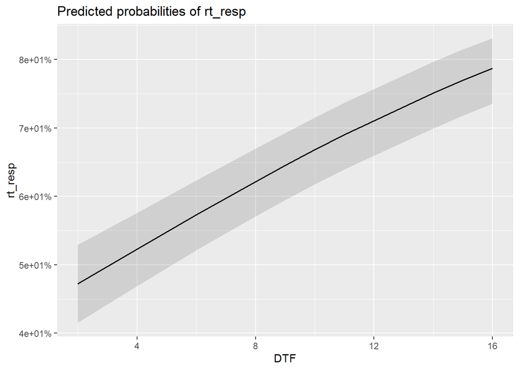

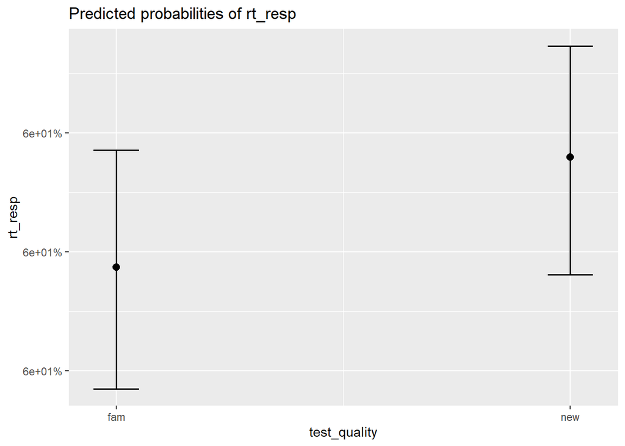

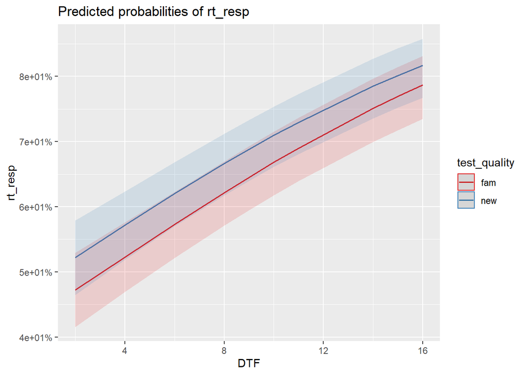

```
## Generalized linear mixed model fit by maximum likelihood (Laplace
##   Approximation) [glmerMod]
##  Family: binomial  ( logit )
## Formula: rt_resp ~ DTAF * test_quality + (1 | workerId)
##    Data: tdlmm
##
##      AIC      BIC   logLik deviance df.resid
##   6048.5   6080.9  -3019.3   6038.5     4803
##
## Scaled residuals:
##     Min      1Q  Median      3Q     Max
## -4.5477 -0.9803  0.5038  0.7977  2.0697
##
## Random effects:
##  Groups   Name        Variance Std.Dev.
##  workerId (Intercept) 0.4581   0.6769
## Number of obs: 4808, groups:  workerId, 50
##
## Fixed effects:
##                      Estimate Std. Error z value Pr(>|z|)
## (Intercept)          -2.38188    0.38436  -6.197 5.75e-10 ***
## DTAF                  0.20335    0.02743   7.415 1.22e-13 ***
## test_qualitynew      -0.28880    0.54077  -0.534    0.593
## DTAF:test_qualitynew  0.03461    0.03991   0.867    0.386
## ---
## Signif. codes:  0 '***' 0.001 '**' 0.01 '*' 0.05 '.' 0.1 ' ' 1
##
## Correlation of Fixed Effects:
##             (Intr) DTAF   tst_ql
## DTAF        -0.962
## test_qltynw -0.665  0.681
## DTAF:tst_ql  0.659 -0.684 -0.993
```

```
## Package `effects` is not available, but needed for `ggeffect()`. Either install package `effects`, or use `ggpredict()`. Calling `ggpredict()` now.FALSE
```

```
## Data were 'prettified'. Consider using `terms="DTAF [all]"` to get smooth plots.
```

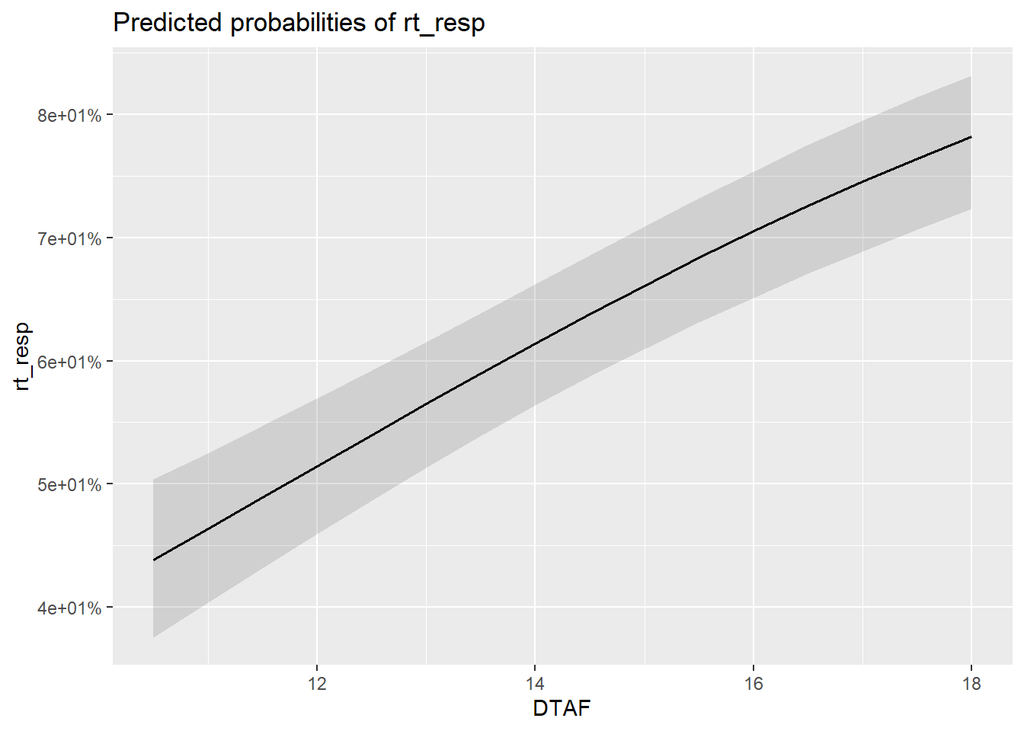

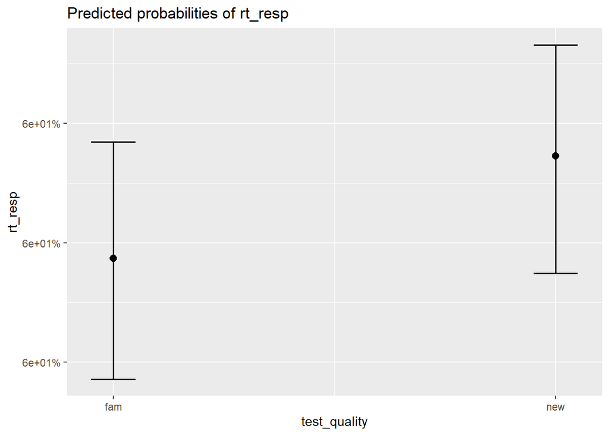

```
## Data were 'prettified'. Consider using `terms="DTAF [all]"` to get smooth plots.
```

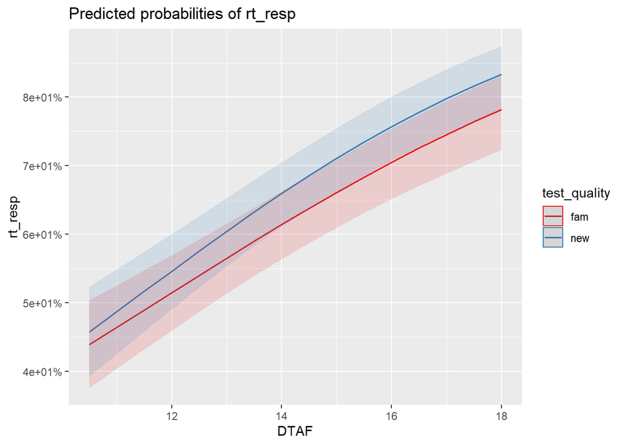

```
## Generalized linear mixed model fit by maximum likelihood (Laplace
##   Approximation) [glmerMod]
##  Family: binomial  ( logit )
## Formula: rt_resp ~ DTAN * test_quality + (1 | workerId)
##    Data: tdlmm
##
##      AIC      BIC   logLik deviance df.resid
##   6139.1   6171.5  -3064.5   6129.1     4803
##
## Scaled residuals:
##     Min      1Q  Median      3Q     Max
## -3.3994 -1.0280  0.5352  0.8192  1.8806
##
## Random effects:
##  Groups   Name        Variance Std.Dev.
##  workerId (Intercept) 0.4403   0.6636
## Number of obs: 4808, groups:  workerId, 50
##
## Fixed effects:
##                      Estimate Std. Error z value Pr(>|z|)
## (Intercept)          -1.76303    0.58624  -3.007 0.002635 **
## DTAN                  0.15798    0.04281   3.690 0.000224 ***
## test_qualitynew      -0.43655    0.81146  -0.538 0.590590
## DTAN:test_qualitynew  0.04557    0.06009   0.758 0.448263
## ---
## Signif. codes:  0 '***' 0.001 '**' 0.01 '*' 0.05 '.' 0.1 ' ' 1
##
## Correlation of Fixed Effects:
##             (Intr) DTAN   tst_ql
## DTAN        -0.984
## test_qltynw -0.704  0.711
## DTAN:tst_ql  0.701 -0.712 -0.997
```

```
## Package `effects` is not available, but needed for `ggeffect()`. Either install package `effects`, or use `ggpredict()`. Calling `ggpredict()` now.FALSE
```

```
## Data were 'prettified'. Consider using `terms="DTAN [all]"` to get smooth plots.
```

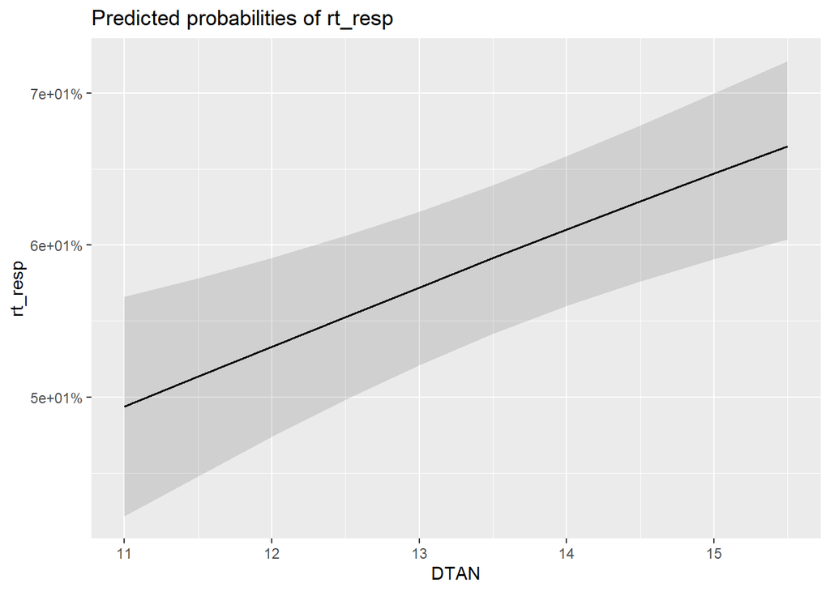

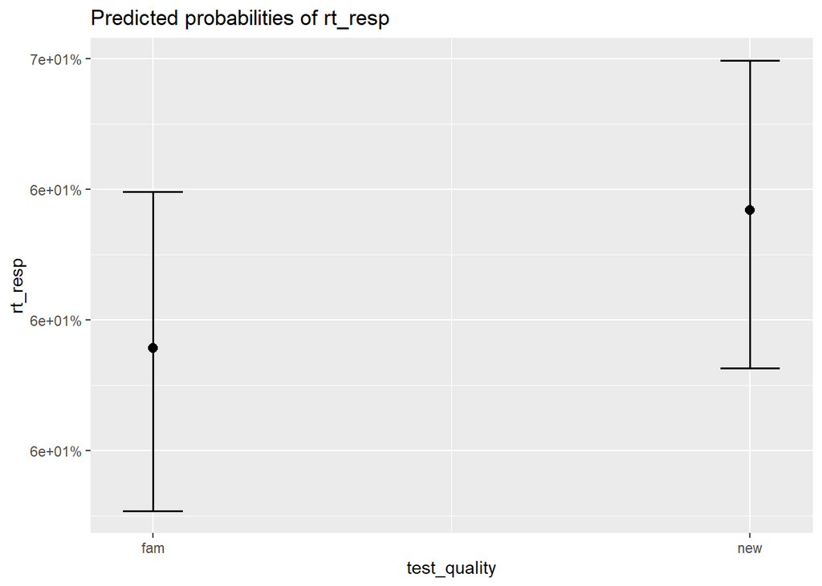

```
## Data were 'prettified'. Consider using `terms="DTAN [all]"` to get smooth plots.
```

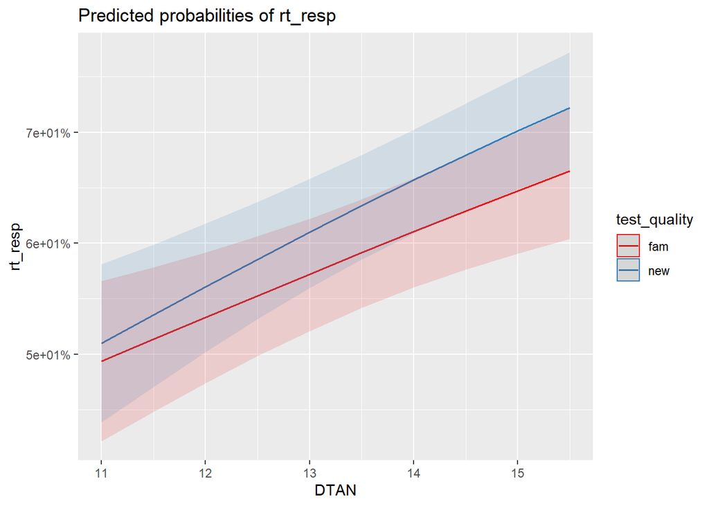

```
## Generalized linear mixed model fit by maximum likelihood (Laplace
##   Approximation) [glmerMod]
##  Family: binomial  ( logit )
## Formula: rt_resp ~ DTN_byPhase * test_quality + (1 | workerId)
##    Data: tdlmm
##
##      AIC      BIC   logLik deviance df.resid
##   6142.1   6174.5  -3066.0   6132.1     4803
##
## Scaled residuals:
##     Min      1Q  Median      3Q     Max
## -3.2974 -1.0283  0.5395  0.8211  1.8696
##
## Random effects:
##  Groups   Name        Variance Std.Dev.
##  workerId (Intercept) 0.4399   0.6633
## Number of obs: 4808, groups:  workerId, 50
##
## Fixed effects:
##                             Estimate Std. Error z value Pr(>|z|)
## (Intercept)                 -1.39080    0.55349  -2.513  0.01198 *
## DTN_byPhase                  0.12552    0.03883   3.232  0.00123 **
## test_qualitynew             -0.75711    0.77705  -0.974  0.32989
## DTN_byPhase:test_qualitynew  0.06680    0.05539   1.206  0.22788
## ---
## Signif. codes:  0 '***' 0.001 '**' 0.01 '*' 0.05 '.' 0.1 ' ' 1
##
## Correlation of Fixed Effects:
##             (Intr) DTN_bP tst_ql
## DTN_byPhase -0.982
## test_qltynw -0.691  0.698
## DTN_byPhs:_  0.687 -0.699 -0.997
## convergence code: 0
## Model failed to converge with max|grad| = 0.0021137 (tol = 0.002, component 1)
```

```
## Package `effects` is not available, but needed for `ggeffect()`. Either install package `effects`, or use `ggpredict()`. Calling `ggpredict()` now.FALSE
```

```
## Data were 'prettified'. Consider using `terms="DTN_byPhase [all]"` to get smooth plots.
```

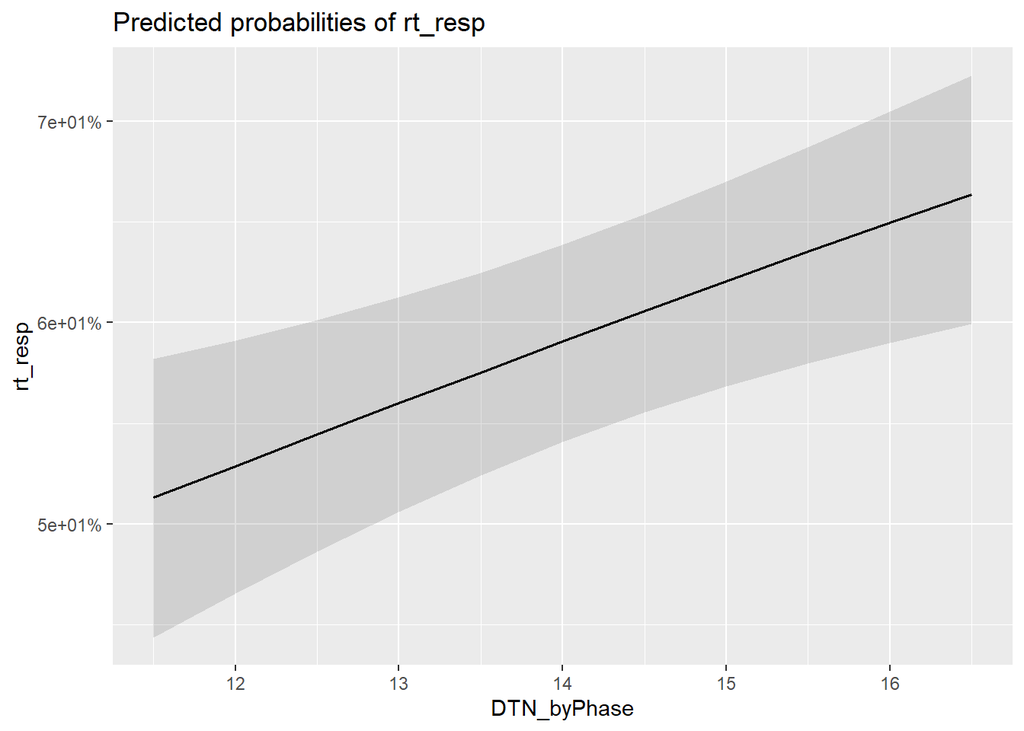

[figure not shown]

```
## Data were 'prettified'. Consider using `terms="DTN_byPhase [all]"` to get smooth plots.
```

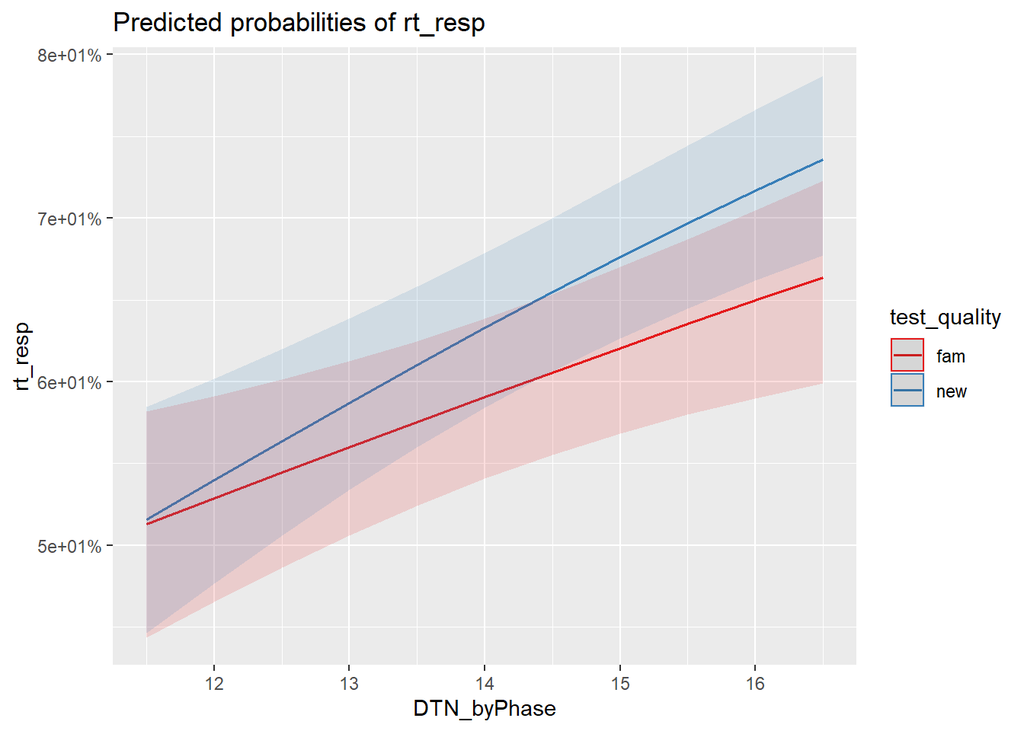

|  | rt_resp |  |  |  | rt_resp |  |  |  | rt_resp |  |  |  | rt_resp |  |  |  | rt_resp |  |  |  |
| --- | --- | --- | --- | --- | --- | --- | --- | --- | --- | --- | --- | --- | --- | --- | --- | --- | --- | --- | --- | --- |
| Predictors | Log-Odds | std. Error | CI | p | Log-Odds | std. Error | CI | p | Log-Odds | std. Error | CI | p | Log-Odds | std. Error | CI | p | Log-Odds | std. Error | CI | p |
| (Intercept) | -0.26 | 0.14 | -0.53 – 0.01 | 0.055 | -0.31 | 0.13 | -0.56 – -0.07 | **0.013** | -2.38 | 0.38 | -3.14 – -1.63 | **<0.001** | -1.76 | 0.59 | -2.91 – -0.61 | **0.003** | -1.39 | 0.55 | -2.48 – -0.31 | **0.012** |
| stimtype [D2] | 0.58 | 0.14 | 0.31 – 0.84 | **<0.001** |  |  |  |  |  |  |  |  |  |  |  |  |  |  |  |  |
| stimtype [D3] | 0.45 | 0.14 | 0.18 – 0.71 | **0.001** |  |  |  |  |  |  |  |  |  |  |  |  |  |  |  |  |
| stimtype [D4] | 0.83 | 0.14 | 0.56 – 1.10 | **<0.001** |  |  |  |  |  |  |  |  |  |  |  |  |  |  |  |  |
| stimtype [D5] | 1.38 | 0.14 | 1.10 – 1.66 | **<0.001** |  |  |  |  |  |  |  |  |  |  |  |  |  |  |  |  |
| test_quality [new] | 0.20 | 0.14 | -0.07 – 0.46 | 0.147 | 0.20 | 0.12 | -0.03 – 0.43 | 0.088 | -0.29 | 0.54 | -1.35 – 0.77 | 0.593 | -0.44 | 0.81 | -2.03 – 1.15 | 0.591 | -0.76 | 0.78 | -2.28 – 0.77 | 0.330 |
| stimtype [D2] * test_quality [new] | -0.19 | 0.19 | -0.57 – 0.19 | 0.331 |  |  |  |  |  |  |  |  |  |  |  |  |  |  |  |  |
| stimtype [D3] * test_quality [new] | 0.39 | 0.19 | 0.00 – 0.77 | **0.048** |  |  |  |  |  |  |  |  |  |  |  |  |  |  |  |  |
| stimtype [D4] * test_quality [new] | -0.33 | 0.19 | -0.71 – 0.05 | 0.088 |  |  |  |  |  |  |  |  |  |  |  |  |  |  |  |  |
| stimtype [D5] * test_quality [new] | 0.08 | 0.21 | -0.32 – 0.49 | 0.683 |  |  |  |  |  |  |  |  |  |  |  |  |  |  |  |  |
| DTF |  |  |  |  | 0.10 | 0.01 | 0.08 – 0.12 | **<0.001** |  |  |  |  |  |  |  |  |  |  |  |  |
| DTF * test_quality [new] |  |  |  |  | -0.00 | 0.02 | -0.03 – 0.03 | 0.957 |  |  |  |  |  |  |  |  |  |  |  |  |
| DTAF |  |  |  |  |  |  |  |  | 0.20 | 0.03 | 0.15 – 0.26 | **<0.001** |  |  |  |  |  |  |  |  |
| DTAF * test_quality [new] |  |  |  |  |  |  |  |  | 0.03 | 0.04 | -0.04 – 0.11 | 0.386 |  |  |  |  |  |  |  |  |
| DTAN |  |  |  |  |  |  |  |  |  |  |  |  | 0.16 | 0.04 | 0.07 – 0.24 | **<0.001** |  |  |  |  |
| DTAN * test_quality [new] |  |  |  |  |  |  |  |  |  |  |  |  | 0.05 | 0.06 | -0.07 – 0.16 | 0.448 |  |  |  |  |
| DTN_byPhase |  |  |  |  |  |  |  |  |  |  |  |  |  |  |  |  | 0.13 | 0.04 | 0.05 – 0.20 | **0.001** |
| DTN_byPhase * test_quality [new] |  |  |  |  |  |  |  |  |  |  |  |  |  |  |  |  | 0.07 | 0.06 | -0.04 – 0.18 | 0.228 |
| Random Effects |  |  |  |  |  |  |  |  |  |  |  |  |  |  |  |  |  |  |  |  |
| σ<sup>2</sup> | 3.29 |  |  |  | 3.29 |  |  |  | 3.29 |  |  |  | 3.29 |  |  |  | 3.29 |  |  |  |
| τ<sub>00</sub> | 0.47 <sub>workerId</sub> |  |  |  | 0.47 <sub>workerId</sub> |  |  |  | 0.46 <sub>workerId</sub> |  |  |  | 0.44 <sub>workerId</sub> |  |  |  | 0.44 <sub>workerId</sub> |  |  |  |
| ICC | 0.13 |  |  |  | 0.12 |  |  |  | 0.12 |  |  |  | 0.12 |  |  |  | 0.12 |  |  |  |
| N | 50 <sub>workerId</sub> |  |  |  | 50 <sub>workerId</sub> |  |  |  | 50 <sub>workerId</sub> |  |  |  | 50 <sub>workerId</sub> |  |  |  | 50 <sub>workerId</sub> |  |  |  |
| Observations | 4808 |  |  |  | 4808 |  |  |  | 4808 |  |  |  | 4808 |  |  |  | 4808 |  |  |  |
| Marginal R<sup>2</sup> / Conditional R<sup>2</sup> | 0.059 / 0.177 |  |  |  | 0.050 / 0.168 |  |  |  | 0.035 / 0.153 |  |  |  | 0.012 / 0.128 |  |  |  | 0.011 / 0.128 |  |  |  |
| AIC | 5968.002 |  |  |  | 5995.544 |  |  |  | 6048.562 |  |  |  | 6139.084 |  |  |  | 6142.074 |  |  |  |

### Models #2

```
## Generalized linear mixed model fit by maximum likelihood (Laplace
##   Approximation) [glmerMod]
##  Family: binomial  ( logit )
## Formula: rt_resp ~ total_responses + stimtype * test_quality + (1 | workerId)
##    Data: tdlmm
##
##      AIC      BIC   logLik deviance df.resid
##   5932.1   6009.9  -2954.1   5908.1     4796
##
## Scaled residuals:
##     Min      1Q  Median      3Q     Max
## -5.1393 -0.9351  0.4664  0.7789  2.4303
##
## Random effects:
##  Groups   Name        Variance Std.Dev.
##  workerId (Intercept) 0.4848   0.6963
## Number of obs: 4808, groups:  workerId, 50
##
## Fixed effects:
##                            Estimate Std. Error z value Pr(>|z|)
## (Intercept)                -0.26549    0.13822  -1.921 0.054760 .
## total_responses             0.19511    0.03185   6.126 8.99e-10 ***
## stimtypeD2                  0.58358    0.13727   4.251 2.12e-05 ***
## stimtypeD3                  0.45544    0.13697   3.325 0.000884 ***
## stimtypeD4                  0.83160    0.13865   5.998 2.00e-09 ***
## stimtypeD5                  1.40041    0.14466   9.681  < 2e-16 ***
## test_qualitynew             0.19012    0.13684   1.389 0.164737
## stimtypeD2:test_qualitynew -0.18527    0.19396  -0.955 0.339499
## stimtypeD3:test_qualitynew  0.38431    0.19566   1.964 0.049517 *
## stimtypeD4:test_qualitynew -0.33557    0.19499  -1.721 0.085254 .
## stimtypeD5:test_qualitynew  0.09185    0.20792   0.442 0.658684
## ---
## Signif. codes:  0 '***' 0.001 '**' 0.01 '*' 0.05 '.' 0.1 ' ' 1
##
## Correlation of Fixed Effects:
##             (Intr) ttl_rs stmtD2 stmtD3 stmtD4 stmtD5 tst_ql stD2:_ stD3:_
## totl_rspnss -0.005
## stimtypeD2  -0.495  0.014
## stimtypeD3  -0.496  0.015  0.501
## stimtypeD4  -0.490  0.010  0.495  0.496
## stimtypeD5  -0.470  0.034  0.476  0.477  0.473
## test_qltynw -0.496 -0.008  0.500  0.501  0.496  0.475
## stmtypD2:t_  0.350  0.001 -0.707 -0.354 -0.350 -0.335 -0.705
## stmtypD3:t_  0.347  0.002 -0.349 -0.699 -0.345 -0.331 -0.699  0.493
## stmtypD4:t_  0.348 -0.005 -0.352 -0.352 -0.710 -0.334 -0.702  0.495  0.490
## stmtypD5:t_  0.326  0.006 -0.329 -0.330 -0.326 -0.690 -0.658  0.464  0.460
##             stD4:_
## totl_rspnss
## stimtypeD2
## stimtypeD3
## stimtypeD4
## stimtypeD5
## test_qltynw
## stmtypD2:t_
## stmtypD3:t_
## stmtypD4:t_
## stmtypD5:t_  0.462
## convergence code: 0
## Model failed to converge with max|grad| = 0.00352421 (tol = 0.002, component 1)
```

```
## Package `effects` is not available, but needed for `ggeffect()`. Either install package `effects`, or use `ggpredict()`. Calling `ggpredict()` now.FALSE
```

```
## Data were 'prettified'. Consider using `terms="total_responses [all]"` to get smooth plots.
```

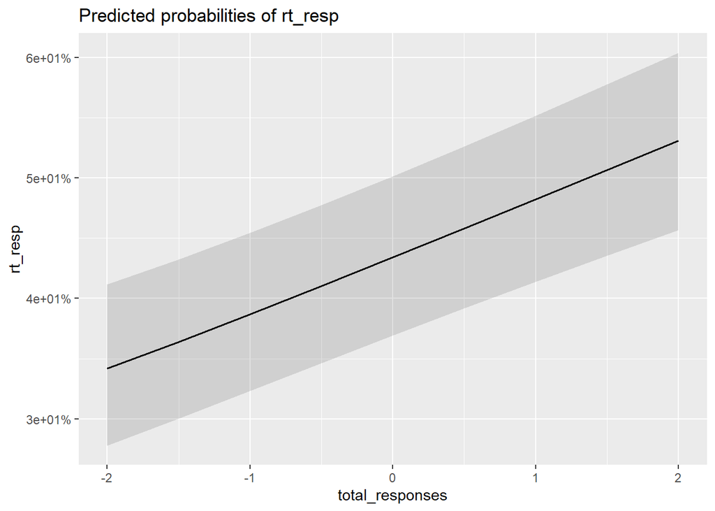

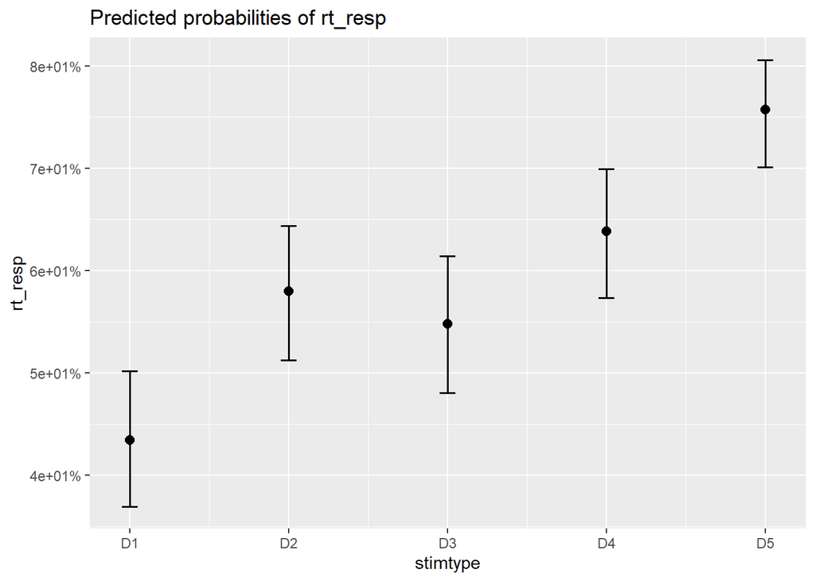

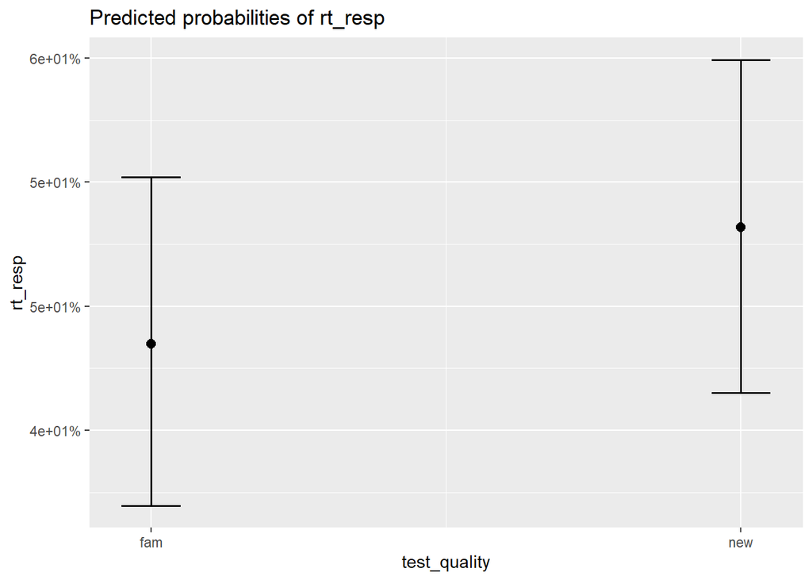

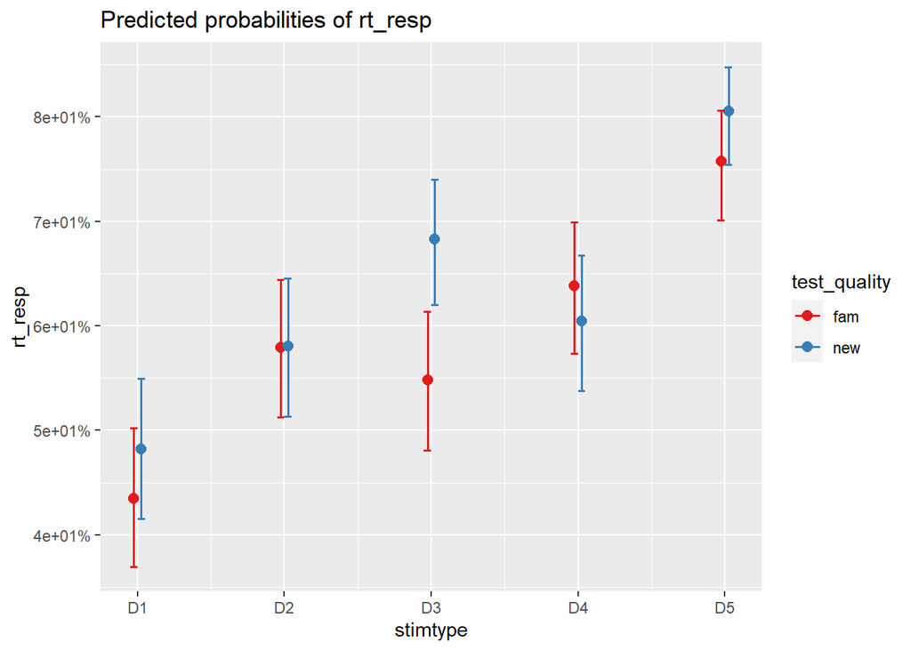

```
## Generalized linear mixed model fit by maximum likelihood (Laplace
##   Approximation) [glmerMod]
##  Family: binomial  ( logit )
## Formula: rt_resp ~ total_responses + DTF * test_quality + (1 | workerId)
##    Data: tdlmm
##
##      AIC      BIC   logLik deviance df.resid
##   5961.0   5999.9  -2974.5   5949.0     4802
##
## Scaled residuals:
##     Min      1Q  Median      3Q     Max
## -5.5761 -0.9468  0.4723  0.7908  2.2371
##
## Random effects:
##  Groups   Name        Variance Std.Dev.
##  workerId (Intercept) 0.4765   0.6903
## Number of obs: 4808, groups:  workerId, 50
##
## Fixed effects:
##                       Estimate Std. Error z value Pr(>|z|)
## (Intercept)         -0.3173789  0.1279246  -2.481   0.0131 *
## total_responses      0.1910016  0.0317100   6.023 1.71e-09 ***
## DTF                  0.1025230  0.0106853   9.595  < 2e-16 ***
## test_qualitynew      0.1934845  0.1186587   1.631   0.1030
## DTF:test_qualitynew -0.0005432  0.0156750  -0.035   0.9724
## ---
## Signif. codes:  0 '***' 0.001 '**' 0.01 '*' 0.05 '.' 0.1 ' ' 1
##
## Correlation of Fixed Effects:
##             (Intr) ttl_rs DTF    tst_ql
## totl_rspnss -0.007
## DTF         -0.544  0.030
## test_qltynw -0.448 -0.009  0.586
## DTF:tst_qlt  0.370  0.003 -0.677 -0.848
```

```
## Package `effects` is not available, but needed for `ggeffect()`. Either install package `effects`, or use `ggpredict()`. Calling `ggpredict()` now.FALSE
## Data were 'prettified'. Consider using `terms="total_responses [all]"` to get smooth plots.
```

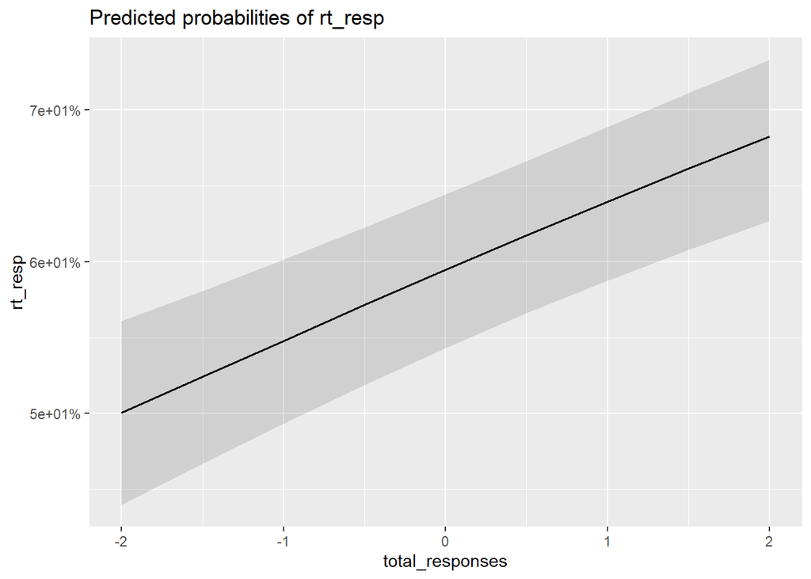

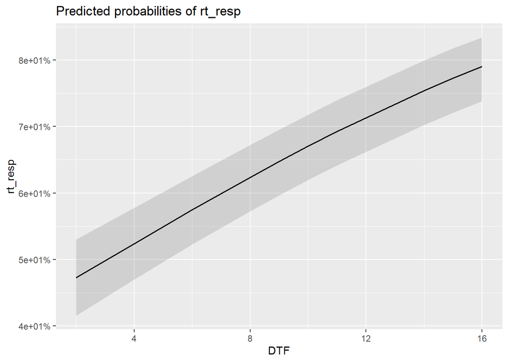

[figure not shown]

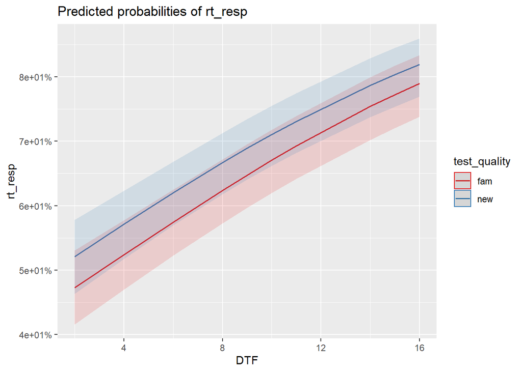

```
## Generalized linear mixed model fit by maximum likelihood (Laplace
##   Approximation) [glmerMod]
##  Family: binomial  ( logit )
## Formula: rt_resp ~ total_responses + DTAF * test_quality + (1 | workerId)
##    Data: tdlmm
##
##      AIC      BIC   logLik deviance df.resid
##   6016.3   6055.2  -3002.2   6004.3     4802
##
## Scaled residuals:
##     Min      1Q  Median      3Q     Max
## -5.2950 -0.9656  0.4921  0.7950  2.2977
##
## Random effects:
##  Groups   Name        Variance Std.Dev.
##  workerId (Intercept) 0.467    0.6833
## Number of obs: 4808, groups:  workerId, 50
##
## Fixed effects:
##                      Estimate Std. Error z value Pr(>|z|)
## (Intercept)          -2.39213    0.38614  -6.195 5.83e-10 ***
## total_responses       0.18364    0.03149   5.831 5.52e-09 ***
## DTAF                  0.20443    0.02755   7.419 1.18e-13 ***
## test_qualitynew      -0.29990    0.54325  -0.552    0.581
## DTAF:test_qualitynew  0.03495    0.04009   0.872    0.383
## ---
## Signif. codes:  0 '***' 0.001 '**' 0.01 '*' 0.05 '.' 0.1 ' ' 1
##
## Correlation of Fixed Effects:
##             (Intr) ttl_rs DTAF   tst_ql
## totl_rspnss -0.012
## DTAF        -0.961  0.016
## test_qltynw -0.664 -0.005  0.681
## DTAF:tst_ql  0.658  0.003 -0.684 -0.993
```

```
## Package `effects` is not available, but needed for `ggeffect()`. Either install package `effects`, or use `ggpredict()`. Calling `ggpredict()` now.FALSE
## Data were 'prettified'. Consider using `terms="total_responses [all]"` to get smooth plots.
```

```
## Data were 'prettified'. Consider using `terms="DTAF [all]"` to get smooth plots.
```

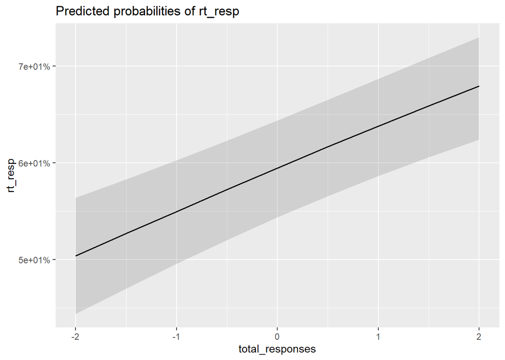

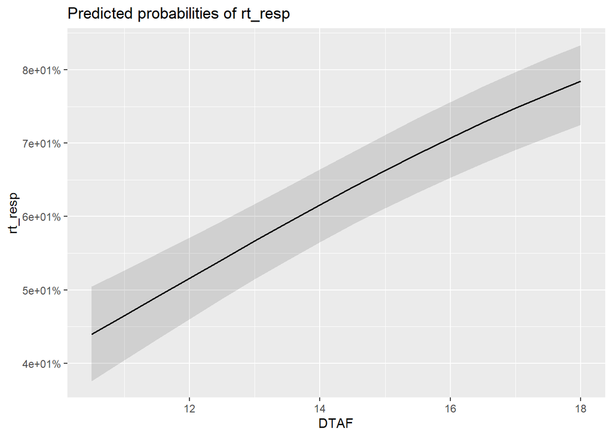

[figure not shown]